# Notebook

```python
import pandas as pd
import matplotlib.pyplot as plt
import seaborn as sns
```

```python
df = pd.read_csv('data_risk.csv')
```

```python
df.head()
```

|  | id | age | education | sex | is_smoking | cigsPerDay | BPMeds | prevalentStroke | prevalentHyp | diabetes | totChol | sysBP | diaBP | BMI | heartRate | glucose | TenYearCHD |
| --- | --- | --- | --- | --- | --- | --- | --- | --- | --- | --- | --- | --- | --- | --- | --- | --- | --- |
| 0 | 0 | 64 | 2.0 | F | YES | 3.0 | 0.0 | 0 | 0 | 0 | 221.0 | 148.0 | 85.0 | NaN | 90.0 | 80.0 | 1 |
| 1 | 1 | 36 | 4.0 | M | NO | 0.0 | 0.0 | 0 | 1 | 0 | 212.0 | 168.0 | 98.0 | 29.77 | 72.0 | 75.0 | 0 |
| 2 | 2 | 46 | 1.0 | F | YES | 10.0 | 0.0 | 0 | 0 | 0 | 250.0 | 116.0 | 71.0 | 20.35 | 88.0 | 94.0 | 0 |
| 3 | 3 | 50 | 1.0 | M | YES | 20.0 | 0.0 | 0 | 1 | 0 | 233.0 | 158.0 | 88.0 | 28.26 | 68.0 | 94.0 | 1 |
| 4 | 4 | 64 | 1.0 | F | YES | 30.0 | 0.0 | 0 | 0 | 0 | 241.0 | 136.5 | 85.0 | 26.42 | 70.0 | 77.0 | 0 |

```python
sns.set()
```

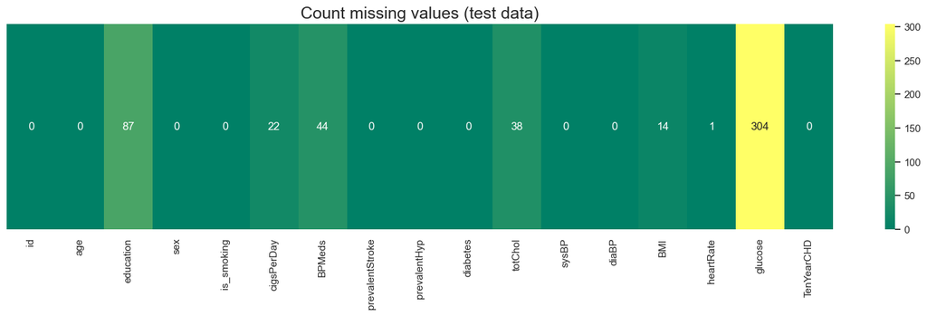

```python
plt.figure(figsize=(20,4))

sns.heatmap((df.isna().sum()).to_frame(name='').T,cmap='summer', annot=True,
             fmt='0.0f').set_title('Count missing values (test data)', fontsize=18)
```

FEATURE ANALYSIS

## TARGET FEATURE

```python
df['age'].describe()
```

```
count    3390.000000
mean       49.542183
std         8.592878
min        32.000000
25%        42.000000
50%        49.000000
75%        56.000000
max        70.000000
Name: age, dtype: float64
```

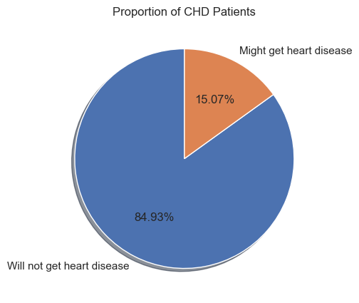

```python
fig ,(ax0) = plt.subplots(1, figsize=(12,5))

# Proportion of CHD Patients
ax0.pie(df['TenYearCHD'].value_counts(), labels=['Will not get heart disease', 'Might get heart disease'], startangle=90, shadow=True, autopct='%.2f%%')
ax0.set_title('Proportion of CHD Patients')

plt.show()
```

Approximately 15% of individuals in this dataset are at risk of developing Coronary Heart Disease (CHD) within a 10-year period

## 1. AGE

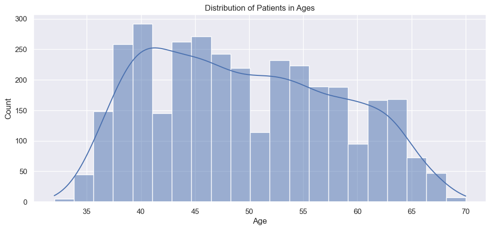

```python
# Age Distribution of All Patients
fig ,(ax0) = plt.subplots(figsize=(12,5))
sns.histplot(data=df, x='age', kde=True, ax=ax0)
ax0.set_title('Distribution of Patients in Ages')
ax0.set_xlabel('Age')

plt.show()
```

The dataset predominantly comprises middle-aged individuals, with the highest density observed in the age range of 40-45 years.

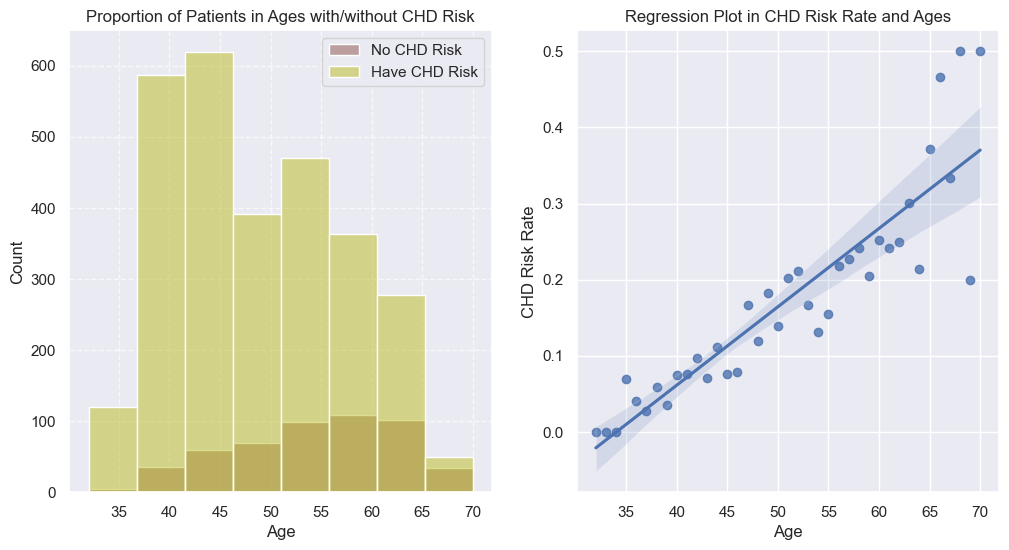

```python
import matplotlib.pyplot as plt
import seaborn as sns

# Create a figure and subplots
fig, (ax0, ax1) = plt.subplots(1, 2, figsize=(12, 6))

# Adjust the color palette and bin width for the histogram
sns.histplot(data=df, x='age', hue='TenYearCHD', ax=ax0,
             palette=['#bcbd22', '#8c564b'], binwidth=5)
ax0.set_title('Proportion of Patients in Ages with/without CHD Risk')
ax0.set_xlabel('Age')
ax0.set_ylabel('Count')
ax0.legend(['No CHD Risk', 'Have CHD Risk'])

# Add grid lines for better readability
ax0.grid(True, linestyle='--', alpha=0.7)

# Regression Plot in CHD Risk Rate and Ages
sns.regplot(x=df.groupby('age')['TenYearCHD'].mean().index,
            y=df.groupby('age')['TenYearCHD'].mean().values, ax=ax1)
ax1.set_xlabel('Age')
ax1.set_ylabel('CHD Risk Rate')
ax1.set_title('Regression Plot in CHD Risk Rate and Ages')

plt.show()
```

From the regression plot of CHD rates and age, it is evident that the likelihood of developing CHD is dependent on age. The risk of CHD rate shows a gradual increase as age increases, indicating a positive correlation between age and the risk of CHD, as indicated by the regression line.

## 2. GENDER

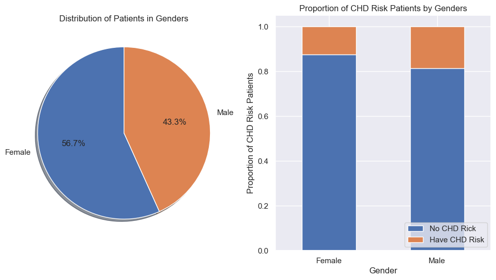

```python
fig, (ax0, ax1) = plt.subplots(1, 2, figsize=(12,6))

# Distribution of Patients in Gender
ax0.pie(df['sex'].value_counts(), labels=['Female', 'Male'], startangle=90, shadow=True, autopct='%.1f%%')
ax0.set_title('Distribution of Patients in Genders')

# Proportion of CHD Risk Patients by Genders
sex_counts = df.groupby(['sex', 'TenYearCHD']).size().unstack()
sex_proportions = sex_counts.div(sex_counts.sum(axis=1), axis=0)
sex_proportions.plot(kind='bar', stacked=True, ax=ax1)
ax1.set_ylabel('Proportion of CHD Risk Patients')
ax1.set_xlabel('Gender')
ax1.set_xticklabels(['Female', 'Male'], rotation=0)
ax1.set_title('Proportion of CHD Risk Patients by Genders')
ax1.legend(['No CHD Rick', 'Have CHD Risk'], loc='lower right')

plt.show()
```

The pie chart indicates that the number of female patients is higher than the number of male patients. However, when we specifically analyze the patients at risk of developing Coronary Heart Disease (CHD) based on their gender, we observe that male patients have a higher risk compared to female patients.

## 3. SMOKING HABIT

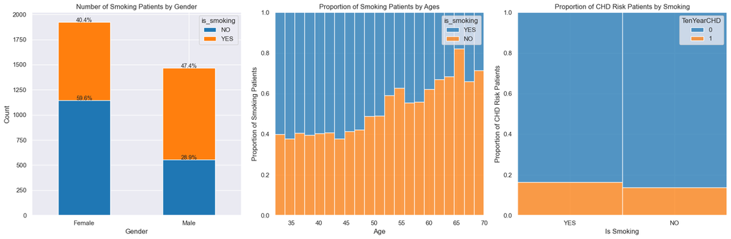

```python
fig, (ax0, ax1, ax2) = plt.subplots(1, 3, figsize=(18, 6))

# Define a color palette
colors = ['#1f77b4', '#ff7f0e']

# Check Proportion of Smoking Patients by their Sex
smoke_counts_sex = df.groupby(['sex', 'is_smoking']).size().unstack()
smoke_counts_sex = smoke_counts_sex.rename(index={'M': 'Male', 'F': 'Female'})
smoke_counts_sex.plot.bar(ax=ax0, stacked=True, color=colors)

totals_sex = smoke_counts_sex.sum(axis=1)
for p in ax0.patches:
    width = p.get_width()
    height = p.get_height()
    x, y = p.get_xy()
    percentage = height / totals_sex[int(x)]
    ax0.annotate(f'{percentage:.1%}', (x + width/2, y + height), ha='center', fontsize=10)

ax0.set_title('Number of Smoking Patients by Gender')
ax0.set_ylabel('Count')
ax0.set_xlabel('Gender')
ax0.set_xticklabels(ax0.get_xticklabels(), rotation=0)

# Check the Proportion of Smoking Patients by Ages
sns.histplot(data=df, x='age', hue='is_smoking', multiple='fill', edgecolor=None, ax=ax1, palette=colors)
ax1.set_title('Proportion of Smoking Patients by Ages')
ax1.set_ylabel('Proportion of Smoking Patients')
ax1.set_xlabel('Age')

# Proportion of CHD Risk Patients by Smoking
sns.histplot(data=df, x='is_smoking', hue='TenYearCHD', multiple='fill', ax=ax2, palette=colors)
ax2.set_title('Proportion of CHD Risk Patients by Smoking')
ax2.set_ylabel('Proportion of CHD Risk Patients')
ax2.set_xlabel('Is Smoking')

plt.tight_layout()
plt.show()
```

From the left figure, we can observe that the proportion of male smokers is higher than that of females, suggesting a higher prevalence of smoking among men.

The right figure reveals a weak relationship between smoking and the risk of Coronary Heart Disease (CHD).

## 4. Number of cigarettes per day

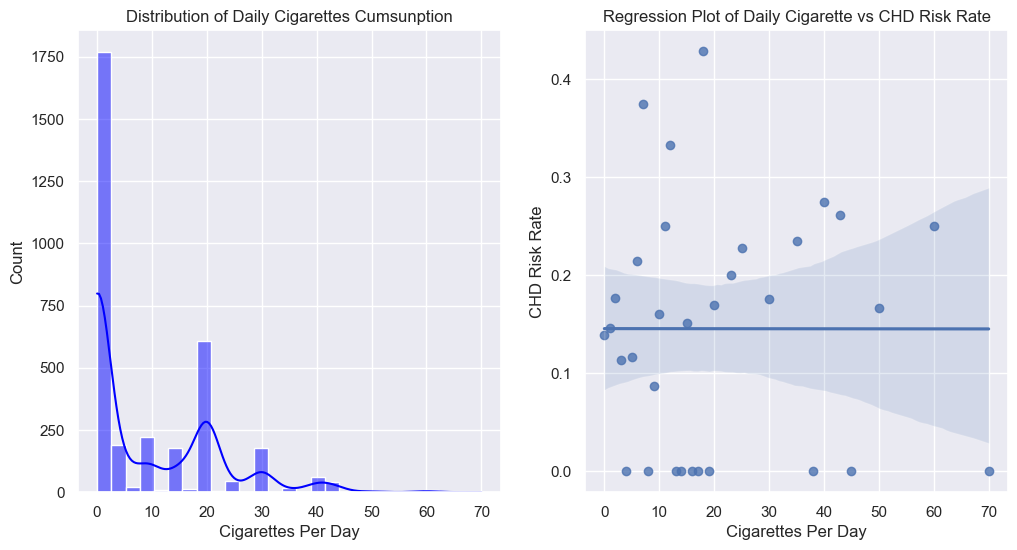

```python
fig, (ax0, ax1) = plt.subplots(1, 2, figsize=(12, 6))

# Distribution of Daily Cigarettes Cumsunption
sns.histplot(x=df['cigsPerDay'], ax=ax0, kde=True, color='blue')
ax0.set_xlabel('Cigarettes Per Day')
ax0.set_title('Distribution of Daily Cigarettes Cumsunption')

# Regression Plot of Daily Cigarette vs CHD Risk Rate
sns.regplot(x=df.groupby(['cigsPerDay'])['TenYearCHD'].mean().index,
            y=df.groupby(['cigsPerDay'])['TenYearCHD'].mean().values, ax=ax1)
ax1.set_xlabel('Cigarettes Per Day')
ax1.set_ylabel('CHD Risk Rate')
ax1.set_title('Regression Plot of Daily Cigarette vs CHD Risk Rate')

plt.show()
```

The histogram depicts that there is a significant deviation in the daily cigarette consumption among patients, indicating a wide distribution of cigarette intake.

The regression line analysis indicates a weak correlation between the incidence of coronary heart disease(CHD) and the number of cigarettes smoked per day. This result suggests that the relationship between smoking and coronary heart disease(CHD) can vary among individuals.

```python
# Define pie and bar chart
def get_pie_bar(category, label, title):
    fig, (ax0, ax1)=plt.subplots(1, 2, figsize=(10,4))
    proportion = df[category].value_counts()/df[category].value_counts().sum()
    ax0.pie(proportion, startangle=90, shadow=True,
            labels=['No ' + label, label], autopct='%.1f%%', explode=(0.1, 0))
    ax0.set_title('Proportion of Patients ' + title)

    chd_counts = df.groupby([category, 'TenYearCHD']).size().unstack()
    chd_proportions = chd_counts.div(chd_counts.sum(axis=1), axis=0)
    chd_proportions.plot(kind='bar', stacked=True, ax=ax1)
    ax1.set_title('Proportion of CHD by ' + category)
    ax1.set_xlabel('')
    ax1.set_ylabel('Proportion [%]')
    ax1.set_xticklabels(['No ' + label, label], rotation=0)
    ax1.legend(loc='lower left')

    for container in ax1.containers:
        for rect in container:
            width = rect.get_width()
            height = rect.get_height()
            x = rect.get_x()
            y = rect.get_y()
            ax1.annotate(f'{height:.1%}', xy=(x + width / 2, y + height / 2),
                         xytext=(0, 3), textcoords='offset points',
                         ha='center', va='center')
    plt.show()
```

## 5. BP Medicines

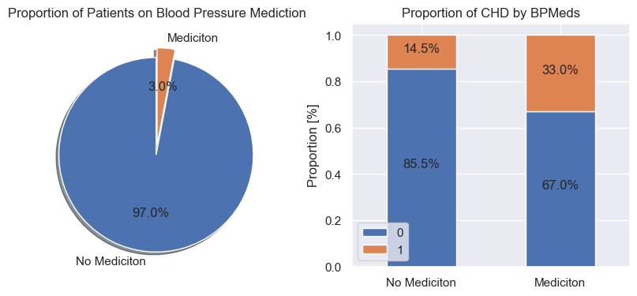

|  | BPMeds |
| --- | --- |
| 0.0 | 3246 |
| 1.0 | 100 |

```python
# Check the relation of BPMeds and CHD
get_pie_bar('BPMeds', 'Mediciton', 'on Blood Pressure Mediction')

df['BPMeds'].value_counts().to_frame()
```

## Prevalent Stroke

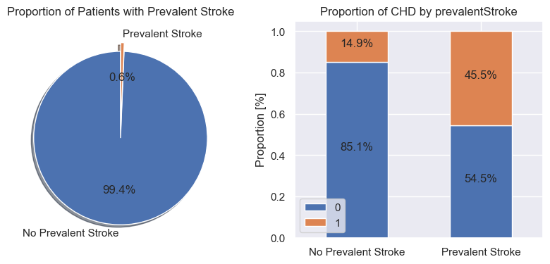

|  | prevalentStroke |
| --- | --- |
| 0 | 3368 |
| 1 | 22 |

```python
# Check the relation of prevalentStroke and CHD
get_pie_bar('prevalentStroke', 'Prevalent Stroke', 'with Prevalent Stroke')

df['prevalentStroke'].value_counts().to_frame()
```

## Prevalent Hypertension

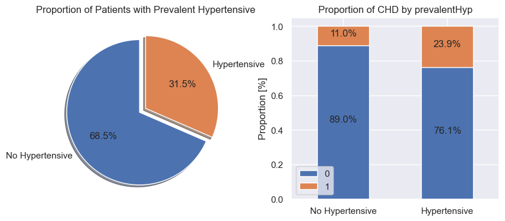

|  | prevalentHyp |
| --- | --- |
| 0 | 2321 |
| 1 | 1069 |

```python
# Check the relation of prevalentHyp and CHD
get_pie_bar('prevalentHyp', 'Hypertensive', 'with Prevalent Hypertensive')

df['prevalentHyp'].value_counts().to_frame()
```

## Diabetes

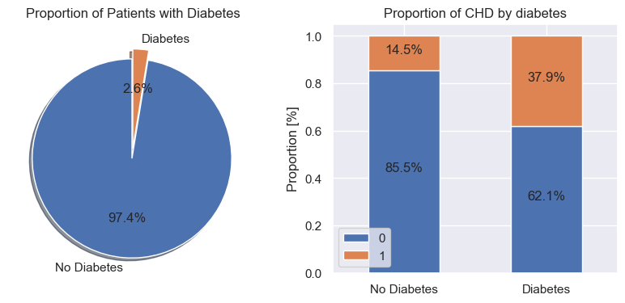

|  | diabetes |
| --- | --- |
| 0 | 3303 |
| 1 | 87 |

```python
# Check the relation of diabetes and CHD
get_pie_bar('diabetes', 'Diabetes', 'with Diabetes')

df['diabetes'].value_counts().to_frame()
```

## Blood Pressure

According to the report from [CDC (Centers for Disease Control and Preventrion)](https://www.cdc.gov/bloodpressure/about.htm), the classified as follows:

| Category | Systolic (mm-Hg) | Diastolic (mm-Hg) |
| --- | --- | --- |
| Normal | <120 | <80 |
| Elevated | 120-129 | <80 |
| High BP | >=130 | >=80 |

```python
# Copy the original df
med_df = df.copy()
# Create categorical columns
med_df.loc[(med_df['sysBP'] < 120) & (med_df['diaBP'] < 80), 'BP_Category'] = 'Normal'
med_df.loc[(med_df['sysBP'] >= 120) & (med_df['sysBP'] < 130) & (med_df['diaBP'] < 80), 'BP_Category'] = 'Elevated'
med_df.loc[(med_df['sysBP'] >= 130) | (med_df['diaBP'] >= 80), 'BP_Category'] = 'High BP'
# Define categorical colors
BP_colors = {'Normal': 'steelblue', 'Elevated': 'darkorange', 'High BP': 'firebrick'}
```

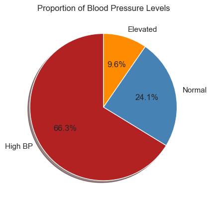

```python
# Proportion of Blood Pressure Levels
plt.pie(med_df['BP_Category'].value_counts(), labels=med_df['BP_Category'].value_counts().index,
        startangle=90, shadow=True, autopct='%.1f%%',
        colors=[BP_colors[val] for val in med_df['BP_Category'].value_counts().index])
plt.title('Proportion of Blood Pressure Levels')
plt.show()
```

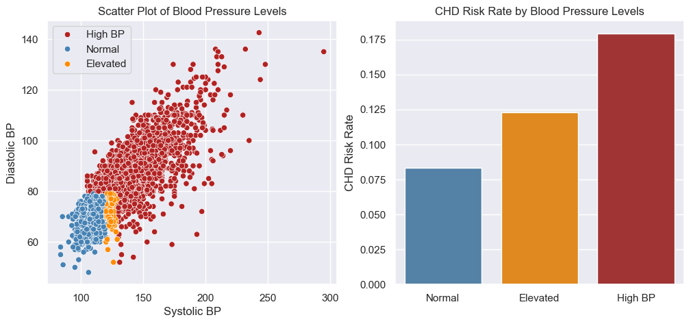

```python
fig, (ax0,ax1) = plt.subplots(1, 2, figsize=(12,5))

# Scatter Plot of Blood Pressure Levels
sns.scatterplot(data=med_df, x='sysBP', y='diaBP', hue='BP_Category',
                palette=BP_colors, ax=ax0)
ax0.set_xlabel('Systolic BP')
ax0.set_ylabel('Diastolic BP')
ax0.set_title('Scatter Plot of Blood Pressure Levels')
ax0.legend(title='')

# CHD Risk Rate by Blood Pressure Levels
BP_CHD = med_df.groupby('BP_Category')['TenYearCHD'].mean().to_frame()
BP_CHD_sorted = BP_CHD.sort_values(by='TenYearCHD')
sns.barplot(data=BP_CHD_sorted, x=BP_CHD_sorted.index, y='TenYearCHD',palette=BP_colors, ax=ax1)
ax1.set_ylabel('CHD Risk Rate')
ax1.set_xlabel('')
ax1.set_title('CHD Risk Rate by Blood Pressure Levels')

plt.show()
```

Based on the scatter plot, it is evident that a significant proportion of individuals in this dataset have a risk of high BP, as indicated by the higher values of systolic and diastolic blood pressure. This suggests that high BP is prevalent among the patients.

The bar chart provides insights into the relationship between high BP risk categories and the rate of CHD. It shows that as the high BP risk increases, the CHD rate also increases. This indicates a positive association between hypertension and the risk of CHD.

## Cholesterol Level

As reported by [Cleveland Clinic](https://my.clevelandclinic.org/health/articles/11920-cholesterol-numbers-what-do-they-mean), high cholesterol is having *total cholesterol above 200 mg/dL*. This condition is also called hyperlipidemia. The cholesterol levels are as follows:

| Cholesterol Levels | Total Cholesterol (mg/dL) |
| --- | --- |
| Dangerous | ≥240 |
| At risk | 200-239 |
| Healthy | <200 |

```python
# Create categorical columns
med_df.loc[(med_df['totChol'] < 200), 'Chol_Category'] = 'Healthy'
med_df.loc[(med_df['totChol'] >= 200) & (med_df['totChol'] < 240), 'Chol_Category'] = 'At risk'
med_df.loc[(med_df['totChol'] >= 240), 'Chol_Category'] = 'Dangerous'
# Define categorical colors
Chol_colors = {'Healthy': 'steelblue', 'At risk': 'darkorange', 'Dangerous': 'firebrick'}
```

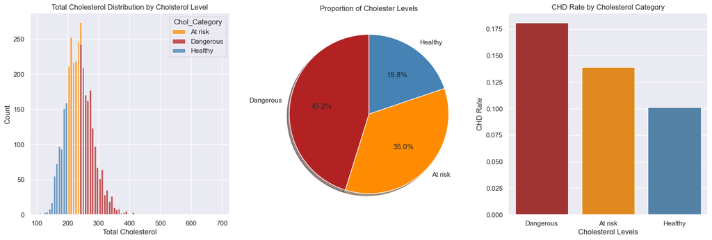

```python
fig, (ax0, ax1, ax2) = plt.subplots(1, 3, figsize=(20,6))

# Total Cholesterol Distribution by Cholsterol Level
sns.histplot(data=med_df, x='totChol', multiple='stack', hue='Chol_Category',
             shrink=0.7, palette=Chol_colors, ax=ax0)
ax0.set_title('Total Cholesterol Distribution by Cholsterol Level')
ax0.set_xlabel('Total Cholesterol')

# Proportion of Cholester Levels
ax1.pie(med_df['Chol_Category'].value_counts(), labels=med_df['Chol_Category'].value_counts().index,
        startangle=90, shadow=True, autopct='%.1f%%',
        colors=[Chol_colors[val] for val in med_df['Chol_Category'].value_counts().index])
ax1.set_title('Proportion of Cholester Levels')

# CHD Rate by Cholesterol Category
med_df_sorted = med_df.sort_values(by='TenYearCHD')
sns.barplot(data=med_df_sorted, x='Chol_Category',y='TenYearCHD', palette=Chol_colors, errorbar=None, ax=ax2)
ax2.set_xlabel('Cholesterol Levels')
ax2.set_ylabel('CHD Rate')
ax2.set_title('CHD Rate by Cholesterol Category')

plt.show()
```

From the pie chart, it can be observed that approximately 20% of the total samples belong to the healthy cholesterol level category. This suggests that the majority of people in this analysis are at risk of hyperlipidemia.

CHD rate by Cholesterol level further supports the notion that higher cholesterol levels increase the CHD rate. The bar chart demonstrates the increasing trend of CHD rate as cholesterol level progress.

## BMI

Although BMI may vary depending on whether the person being measured is physically fit or not, it is still a widely used and measurable indicator for most individuals. **CDC** also provide the [standard weight status categories](https://www.cdc.gov/healthyweight/assessing/bmi/adult_bmi/index.html):

| Weight Status | BMI |
| --- | --- |
| Underweight | <18.5 |
| Healthy | 18.5–24.9 |
| Overweight | 25.0-29.9 |
| Obesity | ≥30.0 |

```python
# Create categorical column
med_df.loc[(med_df['BMI'] < 18.5), 'BMI_Category'] = 'Underweight'
med_df.loc[(med_df['BMI'] >= 18.5) & (med_df['BMI'] < 25), 'BMI_Category'] = 'Healthy'
med_df.loc[(med_df['BMI'] >= 25) & (med_df['BMI'] < 30), 'BMI_Category'] = 'Overweight'
med_df.loc[(med_df['BMI'] >= 30), 'BMI_Category'] = 'Obesity'
# Define categorical colors
BMI_colors = {'Underweight': 'forestgreen', 'Healthy': 'steelblue', 'Overweight': 'darkorange', 'Obesity': 'firebrick'}
```

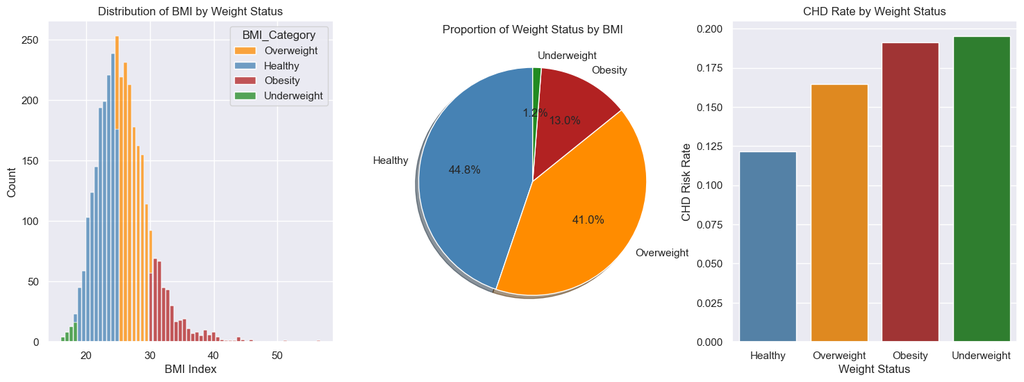

```python
fig, (ax0,ax1,ax2) = plt.subplots(1,3,figsize=(18,6))

# Distribution of BMI by Weight Status
sns.histplot(data=med_df, x='BMI', multiple='stack', hue='BMI_Category',
             shrink=0.8, palette=BMI_colors, ax=ax0)
ax0.set_title('Distribution of BMI by Weight Status')
ax0.set_xlabel('BMI Index')

# Proportion of Weight Status by BMI
ax1.pie(med_df['BMI_Category'].value_counts(), labels=med_df['BMI_Category'].value_counts().index,
        startangle=90, shadow=True, autopct='%.1f%%',
        colors=[BMI_colors[val] for val in med_df['BMI_Category'].value_counts().index])
ax1.set_title('Proportion of Weight Status by BMI')

# CHD Rate by Weight Status
BMI_CHD = med_df.groupby('BMI_Category')['TenYearCHD'].mean().to_frame()
BMI_CHD_sorted = BMI_CHD.sort_values(by='TenYearCHD')
sns.barplot(data=BMI_CHD_sorted, x=BMI_CHD_sorted.index, y='TenYearCHD',palette=BMI_colors, ax=ax2)
ax2.set_title('CHD Rate by Weight Status')
ax2.set_xlabel('Weight Status')
ax2.set_ylabel('CHD Risk Rate')

plt.show()
```

The bar analysis illustrates a positive correlation between weight levels and the rate of Coronary Heart Disease (CHD). As weight increases, the CHD rate also tends to increase. Interestingly, the underweight level exhibits a similar CHD rate to the obesity level.

The underweight level exhibits a similar CHD rate to the obesity level. This result suggests a potential risk of CHD among individuals who are underweight.

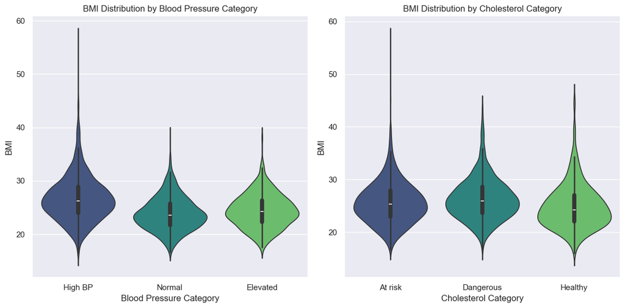

```python
fig, (ax0, ax1) = plt.subplots(1, 2, figsize=(12, 6))

# BMI Distribution by Blood Pressure Category (Violin Plot)
sns.violinplot(data=med_df, x='BP_Category', y='BMI', palette='viridis', ax=ax0)
ax0.set_title('BMI Distribution by Blood Pressure Category')
ax0.set_xlabel('Blood Pressure Category')
ax0.set_ylabel('BMI')

# BMI Distribution by Cholesterol Category (Violin Plot)
sns.violinplot(data=med_df, x='Chol_Category', y='BMI', palette='viridis', ax=ax1)
ax1.set_title('BMI Distribution by Cholesterol Category')
ax1.set_xlabel('Cholesterol Category')
ax1.set_ylabel('BMI')

plt.tight_layout()
plt.show()
```

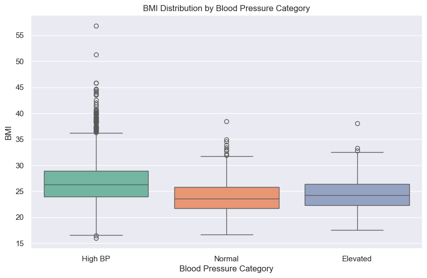

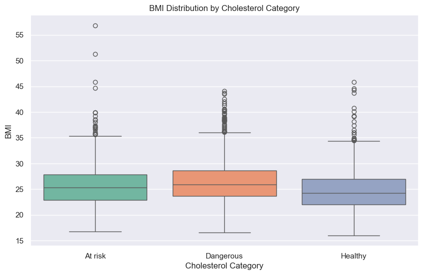

```python
import seaborn as sns
import matplotlib.pyplot as plt

# Create box plot for BMI distribution by BP category
plt.figure(figsize=(10, 6))
sns.boxplot(data=med_df, x='BP_Category', y='BMI', palette='Set2')
plt.title('BMI Distribution by Blood Pressure Category')
plt.xlabel('Blood Pressure Category')
plt.ylabel('BMI')
plt.show()

# Create box plot for BMI distribution by Cholesterol category
plt.figure(figsize=(10, 6))
sns.boxplot(data=med_df, x='Chol_Category', y='BMI', palette='Set2')
plt.title('BMI Distribution by Cholesterol Category')
plt.xlabel('Cholesterol Category')
plt.ylabel('BMI')
plt.show()
```

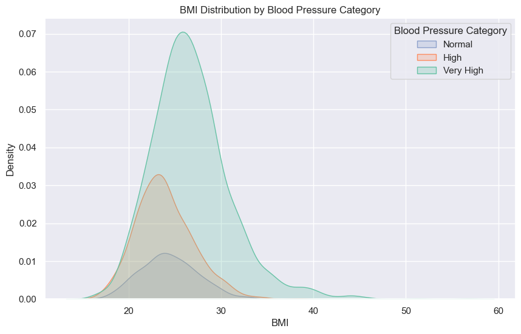

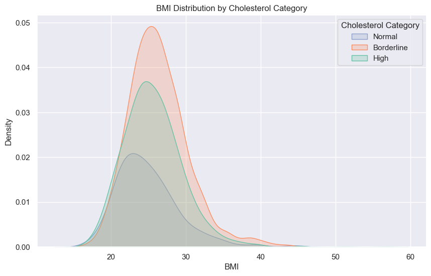

```python
import seaborn as sns
import matplotlib.pyplot as plt


# Create KDE plot for BMI distribution by BP category
plt.figure(figsize=(10, 6))
sns.kdeplot(data=med_df, x='BMI', hue='BP_Category', fill=True, palette='Set2')
plt.title('BMI Distribution by Blood Pressure Category')
plt.xlabel('BMI')
plt.ylabel('Density')
plt.legend(title='Blood Pressure Category', labels=['Normal', 'High', 'Very High'])
plt.show()

# Create KDE plot for BMI distribution by Cholesterol category
plt.figure(figsize=(10, 6))
sns.kdeplot(data=med_df, x='BMI', hue='Chol_Category', fill=True, palette='Set2')
plt.title('BMI Distribution by Cholesterol Category')
plt.xlabel('BMI')
plt.ylabel('Density')
plt.legend(title='Cholesterol Category', labels=['Normal', 'Borderline', 'High'])
plt.show()
```

As we know, there is a strong correlation between obesity and cardiovascular disease. While BMI measurement may not be 100% accurate, it can provide a reliable indication of whether an individual is overweight and can help assess their risk of developing cardiovascular disease.

## Heart Rate

According to information from the British Heart Foundation, the normal range for heart rate is typically between 60 beats per minute (bpm) and 100 bpm. However, it is important to note that heart rate can vary significantly depending on factors such as the individual's current state or the effects of age.

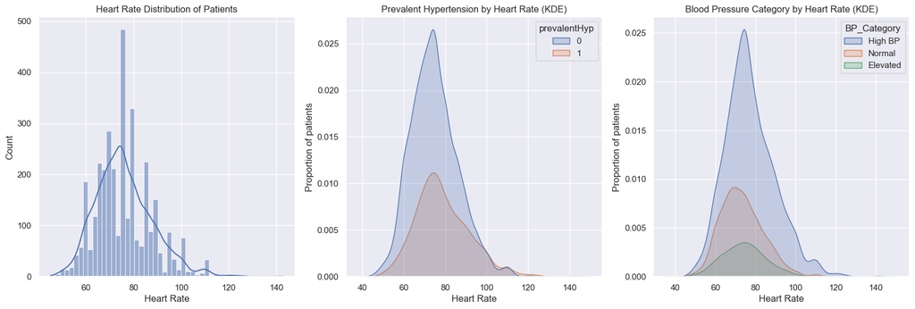

```python
import seaborn as sns
import matplotlib.pyplot as plt

fig, (ax0,ax1, ax2) = plt.subplots(1, 3, figsize=(20, 6))

# Heart Rate Distribution of Patients
sns.histplot(data=med_df, x='heartRate', kde=True, ax=ax0)
ax0.set_xlabel('Heart Rate')
ax0.set_title('Heart Rate Distribution of Patients')
# Proportion of Prevalent Hypertension by Heart Rate (with KDE)
sns.kdeplot(data=med_df, x='heartRate', hue='prevalentHyp', fill=True, ax=ax1)
ax1.set_xlabel('Heart Rate')
ax1.set_ylabel('Proportion of patients')
ax1.set_title('Prevalent Hypertension by Heart Rate (KDE)')

# Proportion of Prevalent Hypertension by Heart Rate (with KDE)
sns.kdeplot(data=med_df, x='heartRate', hue='BP_Category', fill=True, ax=ax2)
ax2.set_xlabel('Heart Rate')
ax2.set_ylabel('Proportion of patients')
ax2.set_title('Blood Pressure Category by Heart Rate (KDE)')

plt.show()
```

The right plot displays the proportion of patients in different blood pressure categories based on their heart rates. It demonstrates that as the heart rate increases, the proportion of patients in the high BP category also tends to increase.

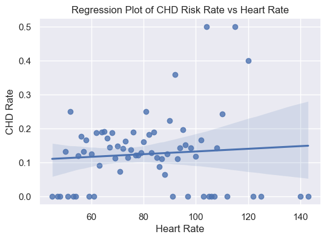

```python
# Regression Plot of CHD Rate and Heart Rate
plt.figure(figsize=(6,4))
sns.regplot(x=med_df.groupby('heartRate')['TenYearCHD'].mean().index,
            y=med_df.groupby('heartRate')['TenYearCHD'].mean().values)
plt.xlabel('Heart Rate')
plt.ylabel('CHD Rate')
plt.title('Regression Plot of CHD Risk Rate vs Heart Rate')
plt.show()
```

## Glucose Level

Blood glucose level is a risk factor for diabetes, and it is typically measured using fasting blood glucose concentration. The **World Health Organization (WHO)** provides [risk categories](https://www.who.int/data/gho/indicator-metadata-registry/imr-details/2380) based on the measured values, as follows:

| Status | Glucose Level (mg/dL) |
| --- | --- |
| Low sugar | <70 |
| Normal | 70-99 |
| At risk | 100-125 |
| Diabetes | >=126 |

```python
# Create categorical column
med_df.loc[(med_df['glucose'] < 70), 'Glucose_Category'] = 'Low Sugar'
med_df.loc[(med_df['glucose'] >= 70) & (med_df['glucose'] < 100), 'Glucose_Category'] = 'Normal'
med_df.loc[(med_df['glucose'] >= 100) & (med_df['glucose'] < 126), 'Glucose_Category'] = 'At risk'
med_df.loc[(med_df['glucose'] > 126), 'Glucose_Category'] = 'Diabetes'
# Define categorical colors
glucose_colors = {'Low Sugar': 'forestgreen', 'Normal': 'steelblue', 'At risk': 'darkorange', 'Diabetes': 'firebrick'}
```

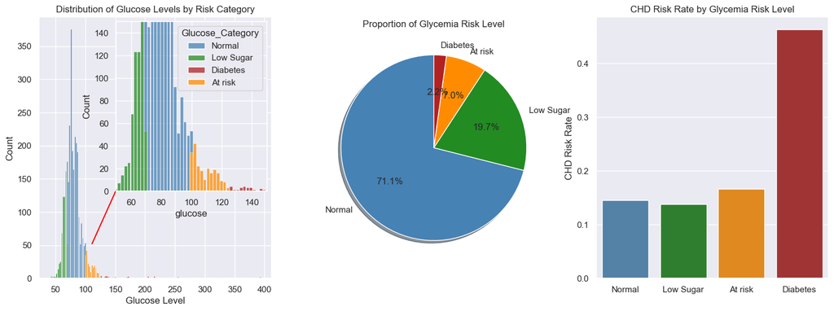

```python
from mpl_toolkits.axes_grid1.inset_locator import inset_axes

fig, (ax0, ax1, ax2) = plt.subplots(1, 3, figsize=(18, 6))

# Distribution of Glucose Levels by Risk Category
sns.histplot(data=med_df, x='glucose', multiple='stack', hue='Glucose_Category', shrink=0.8, palette= glucose_colors, ax=ax0)
ax0.set_title('Distribution of Glucose Levels by Risk Category')
ax0.set_xlabel('Glucose Level')

# Inset Axes
ax_inset = inset_axes(ax0, width='65%', height='65%')
sns.histplot(data=med_df, x='glucose', multiple='stack', hue='Glucose_Category', shrink=0.8, palette=glucose_colors, ax=ax_inset)
ax_inset.set_xlim([50, 150])
ax_inset.set_ylim([0, 150])
arrowprops = {'arrowstyle': '->', 'linewidth': 1.5, 'color': 'red'}
ax0.annotate('', xy=(160, 150), xytext=(110, 50), arrowprops=arrowprops)

# Proportion of Glycemia Risk Level
ax1.pie(med_df['Glucose_Category'].value_counts(), labels=med_df['Glucose_Category'].value_counts().index,
        startangle=90, shadow=True, autopct='%.1f%%',
        colors=[glucose_colors[val] for val in med_df['Glucose_Category'].value_counts().index])
ax1.set_title('Proportion of Glycemia Risk Level')

# CHD Risk Rate by Glycemia Risk Level
med_df_sorted = med_df.sort_values(by='TenYearCHD')
sns.barplot(data=med_df_sorted, x='Glucose_Category', y='TenYearCHD', palette=glucose_colors, errorbar=None, ax=ax2)
ax2.set_xlabel('')
ax2.set_ylabel('CHD Risk Rate')
ax2.set_title('CHD Risk Rate by Glycemia Risk Level')

plt.show()
```

From the histogram, we observe that the majority of patients are concentrated in the glucose level range of around 80 mg/dL

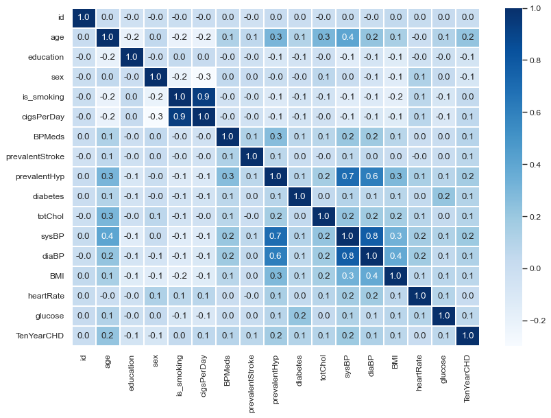

```python
import numpy as np
df['sex'] = df.sex.replace(['M','F'],[0,1])
df['is_smoking'] = df.is_smoking.replace(['YES', 'NO'],[1,0])
target_var = 'TenYearCHD'
df_ordered = pd.concat([df.drop(target_var,axis=1), df[target_var]],axis=1)
corr = df_ordered.corr(method='spearman')


# # Create a mask so that we see the correlation values only once
# mask = np.zeros_like(corr)
# mask[np.triu_indices_from(mask,1)] = True

# Plot the heatmap correlation
plt.figure(figsize=(12,8), dpi=80)
sns.heatmap(corr, annot=True, cmap='Blues', fmt='.1f', linewidths=0.2)
plt.show()
```